# DSC540 Project 1

DePaul University  
Ilyas Ustun, PhD  
Chicago, IL

```python
import sklearn
sklearn.__version__
```

```
'0.23.1'
```

```python
from sklearn.model_selection import train_test_split
from sklearn import metrics

import matplotlib.pyplot as plt
import pandas as pd
import numpy as np
import seaborn as sns
```

```python
pd.set_option('display.max_columns', 100)
```

### These are the packages I used

```python
# Your package imports here
%matplotlib inline

from sklearn.linear_model import LogisticRegression
from sklearn.neighbors import KNeighborsClassifier
from sklearn.naive_bayes import GaussianNB
from sklearn import preprocessing
from sklearn.model_selection import StratifiedKFold, cross_val_predict, cross_val_score
from sklearn.ensemble import ExtraTreesClassifier

#ignore warnings
import warnings
warnings.filterwarnings('ignore')
```

## Rules

- Do not change the code already present in the notebook.
- Write your code under the corresponding questions where you see `# Code here`. You can use more than one cell, if you'd like.
- Provide explanation in a separate Markdown formatted cell.
- You can change the cell type by:
  - Clicking on the outer area of the cell type you want to change,
  - Go to the top, and select either Code or Markdown from the dropdown menu.
- Be concise in your explanations and conclusions.
- Write clear code and provide explanation to functions you create by using `#` comment sign.
- For built-in function and methods you use from libraries, provide a very brief explanation of what they do.
- Try to answer the questions by yourself. Use documentation from pandas, sklearn and similar libraries to solve the problem.
- If you are stuck you can use different resources. Do not find an identical project and copy paste the solutions.
- Write your name before beginning to code.

Important:

- **Do NOT share the solutions with other people.**
- **Do NOT share the solutions on the internet including but not limited to Github and other platforms.**
- Sign the Honor Pledge below indicating that you have agreed to these rules listed here, and any other ethical and honor rules as required by the university.
- **Deliverables:**
  1. The Python Jupyter notebook file named properly with your name. Example: dsc540_project1_john_doe.ipynb
  2. The HTML output of this code notebook names the same way. Example: dsc540_project1_john_doe.html
     - File -> Download as -> HTML

Good Luck!

## The Data

In this project, we will be working with the **Breast Cancer Wisconsin dataset**, which contains 569 examples of malignant and benign tumor cells.  
The Breast Cancer Wisconsin dataset can be found in the UCI Machine Learning Repository, and more detailed information about this dataset can be found at https://archive.ics.uci.edu/ml/datasets/Breast+Cancer+Wisconsin+(Diagnostic).  
The first two columns in the dataset store the unique ID numbers of the examples and the corresponding diagnoses (M = malignant, B = benign), respectively.  
Columns 3-32 contain 30 real-valued features that have been computed from digitized images of the cell nuclei, which can be used to build a model to predict whether a tumor is benign or malignant.

## Load dataset

```python
# Load the dataset from UCI
df = pd.read_csv(
'https://archive.ics.uci.edu/ml/'
'machine-learning-databases'
'/breast-cancer-wisconsin/wdbc.data',
header=None)
```

```python
df.head()
```

|  | 0 | 1 | 2 | 3 | 4 | 5 | 6 | 7 | 8 | 9 | 10 | 11 | 12 | 13 | 14 | 15 | 16 | 17 | 18 | 19 | 20 | 21 | 22 | 23 | 24 | 25 | 26 | 27 | 28 | … |
| --- | --- | --- | --- | --- | --- | --- | --- | --- | --- | --- | --- | --- | --- | --- | --- | --- | --- | --- | --- | --- | --- | --- | --- | --- | --- | --- | --- | --- | --- | --- |
| 0 | 842302 | M | 17.99 | 10.38 | 122.80 | 1001.0 | 0.11840 | 0.27760 | 0.3001 | 0.14710 | 0.2419 | 0.07871 | 1.0950 | 0.9053 | 8.589 | 153.40 | 0.006399 | 0.04904 | 0.05373 | 0.01587 | 0.03003 | 0.006193 | 25.38 | 17.33 | 184.60 | 2019.0 | 0.1622 | 0.6656 | 0.7119 | … |
| 1 | 842517 | M | 20.57 | 17.77 | 132.90 | 1326.0 | 0.08474 | 0.07864 | 0.0869 | 0.07017 | 0.1812 | 0.05667 | 0.5435 | 0.7339 | 3.398 | 74.08 | 0.005225 | 0.01308 | 0.01860 | 0.01340 | 0.01389 | 0.003532 | 24.99 | 23.41 | 158.80 | 1956.0 | 0.1238 | 0.1866 | 0.2416 | … |
| 2 | 84300903 | M | 19.69 | 21.25 | 130.00 | 1203.0 | 0.10960 | 0.15990 | 0.1974 | 0.12790 | 0.2069 | 0.05999 | 0.7456 | 0.7869 | 4.585 | 94.03 | 0.006150 | 0.04006 | 0.03832 | 0.02058 | 0.02250 | 0.004571 | 23.57 | 25.53 | 152.50 | 1709.0 | 0.1444 | 0.4245 | 0.4504 | … |
| 3 | 84348301 | M | 11.42 | 20.38 | 77.58 | 386.1 | 0.14250 | 0.28390 | 0.2414 | 0.10520 | 0.2597 | 0.09744 | 0.4956 | 1.1560 | 3.445 | 27.23 | 0.009110 | 0.07458 | 0.05661 | 0.01867 | 0.05963 | 0.009208 | 14.91 | 26.50 | 98.87 | 567.7 | 0.2098 | 0.8663 | 0.6869 | … |
| 4 | 84358402 | M | 20.29 | 14.34 | 135.10 | 1297.0 | 0.10030 | 0.13280 | 0.1980 | 0.10430 | 0.1809 | 0.05883 | 0.7572 | 0.7813 | 5.438 | 94.44 | 0.011490 | 0.02461 | 0.05688 | 0.01885 | 0.01756 | 0.005115 | 22.54 | 16.67 | 152.20 | 1575.0 | 0.1374 | 0.2050 | 0.4000 | … |

- Since this dataset does not have headers, we will read the data file that I have created.
- Last column is the target column.
- The ID column is dropped.

```python
df = pd.read_csv('WisconsinBreastCancer.csv')
X = df.drop('target', axis=1)
y = df.target
```

```python
X.head()
```

|  | mean radius | mean texture | mean perimeter | mean area | mean smoothness | mean compactness | mean concavity | mean concave points | mean symmetry | mean fractal dimension | radius error | texture error | perimeter error | area error | smoothness error | compactness error | concavity error | concave points error | symmetry error | fractal dimension error | worst radius | worst texture | worst perimeter | worst area | worst smoothness | worst compactness | worst concavity | worst concave points | worst symmetry | … |
| --- | --- | --- | --- | --- | --- | --- | --- | --- | --- | --- | --- | --- | --- | --- | --- | --- | --- | --- | --- | --- | --- | --- | --- | --- | --- | --- | --- | --- | --- | --- |
| 0 | 17.99 | 10.38 | 122.80 | 1001.0 | 0.11840 | 0.27760 | 0.3001 | 0.14710 | 0.2419 | 0.07871 | 1.0950 | 0.9053 | 8.589 | 153.40 | 0.006399 | 0.04904 | 0.05373 | 0.01587 | 0.03003 | 0.006193 | 25.38 | 17.33 | 184.60 | 2019.0 | 0.1622 | 0.6656 | 0.7119 | 0.2654 | 0.4601 | … |
| 1 | 20.57 | 17.77 | 132.90 | 1326.0 | 0.08474 | 0.07864 | 0.0869 | 0.07017 | 0.1812 | 0.05667 | 0.5435 | 0.7339 | 3.398 | 74.08 | 0.005225 | 0.01308 | 0.01860 | 0.01340 | 0.01389 | 0.003532 | 24.99 | 23.41 | 158.80 | 1956.0 | 0.1238 | 0.1866 | 0.2416 | 0.1860 | 0.2750 | … |
| 2 | 19.69 | 21.25 | 130.00 | 1203.0 | 0.10960 | 0.15990 | 0.1974 | 0.12790 | 0.2069 | 0.05999 | 0.7456 | 0.7869 | 4.585 | 94.03 | 0.006150 | 0.04006 | 0.03832 | 0.02058 | 0.02250 | 0.004571 | 23.57 | 25.53 | 152.50 | 1709.0 | 0.1444 | 0.4245 | 0.4504 | 0.2430 | 0.3613 | … |
| 3 | 11.42 | 20.38 | 77.58 | 386.1 | 0.14250 | 0.28390 | 0.2414 | 0.10520 | 0.2597 | 0.09744 | 0.4956 | 1.1560 | 3.445 | 27.23 | 0.009110 | 0.07458 | 0.05661 | 0.01867 | 0.05963 | 0.009208 | 14.91 | 26.50 | 98.87 | 567.7 | 0.2098 | 0.8663 | 0.6869 | 0.2575 | 0.6638 | … |
| 4 | 20.29 | 14.34 | 135.10 | 1297.0 | 0.10030 | 0.13280 | 0.1980 | 0.10430 | 0.1809 | 0.05883 | 0.7572 | 0.7813 | 5.438 | 94.44 | 0.011490 | 0.02461 | 0.05688 | 0.01885 | 0.01756 | 0.005115 | 22.54 | 16.67 | 152.20 | 1575.0 | 0.1374 | 0.2050 | 0.4000 | 0.1625 | 0.2364 | … |

The target vector is `y`.

```python
y.head()
```

```
0    1
1    1
2    1
3    1
4    1
Name: target, dtype: int64
```

### Question 1 [5 points]

How many people have cancer?

> Hint: Should be less than 300!

#### We will call the sum function for counting samples with the value of y = 1, indicating for people who have cancer. The function return 212 which is the number of people have cancer.

```python
# Code here

#Call the sum function for counting samples with the value of y = 1
#The function return 212 which is the number of people have cancer.

print((y == 1).sum())
```

```
212
```

### Answer

- There are 212 number of people have cancer.

### Question 2 [5 points]

Check the data and investigate the column types. Is there any categorical data? Any missing values? How many observations? How many variables are there in the feature set (`X`)?

```python
# Code here

# The function "info" gives the summary of features including:
# Num of observations, num of features, missing values, the data type

X.info()
```

```
<class 'pandas.core.frame.DataFrame'>
RangeIndex: 569 entries, 0 to 568
Data columns (total 30 columns):
 #   Column                   Non-Null Count  Dtype
---  ------                   --------------  -----
 0   mean radius              569 non-null    float64
 1   mean texture             569 non-null    float64
 2   mean perimeter           569 non-null    float64
 3   mean area                569 non-null    float64
 4   mean smoothness          569 non-null    float64
 5   mean compactness         569 non-null    float64
 6   mean concavity           569 non-null    float64
 7   mean concave points      569 non-null    float64
 8   mean symmetry            569 non-null    float64
 9   mean fractal dimension   569 non-null    float64
```

[output cut: 22 more lines]

### Answer

- From above info, there are no categorical data and no missing values. There are 569 observations with 30 variables. All variables are numeric with float64 type.

### Question 3 [5 points]

- Check the statistical summary of numeric features. Do the variables have values close to each other, or is there large differences?
- What is the variable that has the largest value?
- What is the variable that has the smallest value?

```python
# Code here
# Function shows  the statistical summary of numeric features
X.describe()
```

|  | mean radius | mean texture | mean perimeter | mean area | mean smoothness | mean compactness | mean concavity | mean concave points | mean symmetry | mean fractal dimension | radius error | texture error | perimeter error | area error | smoothness error | compactness error | concavity error | concave points error | symmetry error | fractal dimension error | worst radius | worst texture | worst perimeter | worst area | worst smoothness | worst compactness | worst concavity | worst concave points | worst symmetry | … |
| --- | --- | --- | --- | --- | --- | --- | --- | --- | --- | --- | --- | --- | --- | --- | --- | --- | --- | --- | --- | --- | --- | --- | --- | --- | --- | --- | --- | --- | --- | --- |
| count | 569.000000 | 569.000000 | 569.000000 | 569.000000 | 569.000000 | 569.000000 | 569.000000 | 569.000000 | 569.000000 | 569.000000 | 569.000000 | 569.000000 | 569.000000 | 569.000000 | 569.000000 | 569.000000 | 569.000000 | 569.000000 | 569.000000 | 569.000000 | 569.000000 | 569.000000 | 569.000000 | 569.000000 | 569.000000 | 569.000000 | 569.000000 | 569.000000 | 569.000000 | … |
| mean | 14.127292 | 19.289649 | 91.969033 | 654.889104 | 0.096360 | 0.104341 | 0.088799 | 0.048919 | 0.181162 | 0.062798 | 0.405172 | 1.216853 | 2.866059 | 40.337079 | 0.007041 | 0.025478 | 0.031894 | 0.011796 | 0.020542 | 0.003795 | 16.269190 | 25.677223 | 107.261213 | 880.583128 | 0.132369 | 0.254265 | 0.272188 | 0.114606 | 0.290076 | … |
| std | 3.524049 | 4.301036 | 24.298981 | 351.914129 | 0.014064 | 0.052813 | 0.079720 | 0.038803 | 0.027414 | 0.007060 | 0.277313 | 0.551648 | 2.021855 | 45.491006 | 0.003003 | 0.017908 | 0.030186 | 0.006170 | 0.008266 | 0.002646 | 4.833242 | 6.146258 | 33.602542 | 569.356993 | 0.022832 | 0.157336 | 0.208624 | 0.065732 | 0.061867 | … |
| min | 6.981000 | 9.710000 | 43.790000 | 143.500000 | 0.052630 | 0.019380 | 0.000000 | 0.000000 | 0.106000 | 0.049960 | 0.111500 | 0.360200 | 0.757000 | 6.802000 | 0.001713 | 0.002252 | 0.000000 | 0.000000 | 0.007882 | 0.000895 | 7.930000 | 12.020000 | 50.410000 | 185.200000 | 0.071170 | 0.027290 | 0.000000 | 0.000000 | 0.156500 | … |
| 25% | 11.700000 | 16.170000 | 75.170000 | 420.300000 | 0.086370 | 0.064920 | 0.029560 | 0.020310 | 0.161900 | 0.057700 | 0.232400 | 0.833900 | 1.606000 | 17.850000 | 0.005169 | 0.013080 | 0.015090 | 0.007638 | 0.015160 | 0.002248 | 13.010000 | 21.080000 | 84.110000 | 515.300000 | 0.116600 | 0.147200 | 0.114500 | 0.064930 | 0.250400 | … |
| 50% | 13.370000 | 18.840000 | 86.240000 | 551.100000 | 0.095870 | 0.092630 | 0.061540 | 0.033500 | 0.179200 | 0.061540 | 0.324200 | 1.108000 | 2.287000 | 24.530000 | 0.006380 | 0.020450 | 0.025890 | 0.010930 | 0.018730 | 0.003187 | 14.970000 | 25.410000 | 97.660000 | 686.500000 | 0.131300 | 0.211900 | 0.226700 | 0.099930 | 0.282200 | … |
| 75% | 15.780000 | 21.800000 | 104.100000 | 782.700000 | 0.105300 | 0.130400 | 0.130700 | 0.074000 | 0.195700 | 0.066120 | 0.478900 | 1.474000 | 3.357000 | 45.190000 | 0.008146 | 0.032450 | 0.042050 | 0.014710 | 0.023480 | 0.004558 | 18.790000 | 29.720000 | 125.400000 | 1084.000000 | 0.146000 | 0.339100 | 0.382900 | 0.161400 | 0.317900 | … |
| max | 28.110000 | 39.280000 | 188.500000 | 2501.000000 | 0.163400 | 0.345400 | 0.426800 | 0.201200 | 0.304000 | 0.097440 | 2.873000 | 4.885000 | 21.980000 | 542.200000 | 0.031130 | 0.135400 | 0.396000 | 0.052790 | 0.078950 | 0.029840 | 36.040000 | 49.540000 | 251.200000 | 4254.000000 | 0.222600 | 1.058000 | 1.252000 | 0.291000 | 0.663800 | … |

```python
# Find the max value of each feature
print(X.max())
```

```
mean radius                  28.11000
mean texture                 39.28000
mean perimeter              188.50000
mean area                  2501.00000
mean smoothness               0.16340
mean compactness              0.34540
mean concavity                0.42680
mean concave points           0.20120
mean symmetry                 0.30400
mean fractal dimension        0.09744
radius error                  2.87300
texture error                 4.88500
perimeter error              21.98000
area error                  542.20000
smoothness error              0.03113
compactness error             0.13540
concavity error               0.39600
concave points error          0.05279
symmetry error                0.07895
fractal dimension error       0.02984
worst radius                 36.04000
worst texture                49.54000
worst perimeter             251.20000
worst area                 4254.00000
worst smoothness              0.22260
worst compactness             1.05800
worst concavity               1.25200
worst concave points          0.29100
worst symmetry                0.66380
worst fractal dimension       0.20750
dtype: float64
```

```python
# Find the min value of each feature
print(X.min())
```

```
mean radius                  6.981000
mean texture                 9.710000
mean perimeter              43.790000
mean area                  143.500000
mean smoothness              0.052630
mean compactness             0.019380
mean concavity               0.000000
mean concave points          0.000000
mean symmetry                0.106000
mean fractal dimension       0.049960
radius error                 0.111500
texture error                0.360200
perimeter error              0.757000
area error                   6.802000
smoothness error             0.001713
compactness error            0.002252
concavity error              0.000000
concave points error         0.000000
symmetry error               0.007882
fractal dimension error      0.000895
worst radius                 7.930000
worst texture               12.020000
worst perimeter             50.410000
worst area                 185.200000
worst smoothness             0.071170
worst compactness            0.027290
worst concavity              0.000000
worst concave points         0.000000
worst symmetry               0.156500
worst fractal dimension      0.055040
dtype: float64
```

### Answer

- The standard deviation above shows that some variables have large differences in their values.
- The mean perimeter, the mean area, the worst area, and the worst perimeter variables have a large standard deviations which imply the large spread of their values.
- The "worst area" variable has the largest value of 4254.00.
- The "mean concavity" , "mean concave points ", "concavity error ", "concave points error", "worst concavity ", "worst concave points " variables have the smallest value of 0.0.

### Question 4 [5 points]

These features are all engineered from images. I suspect there is some variables with large correlation. Are there largely correlated variables? Why do you think they are largely correlated? Comment on a few.

- Calculate correlation.
- Create a correlation heatmap.
- Comment on largely correlated variables.

```python
# Code here
# The function calculates correlation
corr = X.corr()
corr
```

|  | mean radius | mean texture | mean perimeter | mean area | mean smoothness | mean compactness | mean concavity | mean concave points | mean symmetry | mean fractal dimension | radius error | texture error | perimeter error | area error | smoothness error | compactness error | concavity error | concave points error | symmetry error | fractal dimension error | worst radius | worst texture | worst perimeter | worst area | worst smoothness | worst compactness | worst concavity | worst concave points | worst symmetry | … |
| --- | --- | --- | --- | --- | --- | --- | --- | --- | --- | --- | --- | --- | --- | --- | --- | --- | --- | --- | --- | --- | --- | --- | --- | --- | --- | --- | --- | --- | --- | --- |
| mean radius | 1.000000 | 0.323782 | 0.997855 | 0.987357 | 0.170581 | 0.506124 | 0.676764 | 0.822529 | 0.147741 | -0.311631 | 0.679090 | -0.097317 | 0.674172 | 0.735864 | -0.222600 | 0.206000 | 0.194204 | 0.376169 | -0.104321 | -0.042641 | 0.969539 | 0.297008 | 0.965137 | 0.941082 | 0.119616 | 0.413463 | 0.526911 | 0.744214 | 0.163953 | … |
| mean texture | 0.323782 | 1.000000 | 0.329533 | 0.321086 | -0.023389 | 0.236702 | 0.302418 | 0.293464 | 0.071401 | -0.076437 | 0.275869 | 0.386358 | 0.281673 | 0.259845 | 0.006614 | 0.191975 | 0.143293 | 0.163851 | 0.009127 | 0.054458 | 0.352573 | 0.912045 | 0.358040 | 0.343546 | 0.077503 | 0.277830 | 0.301025 | 0.295316 | 0.105008 | … |
| mean perimeter | 0.997855 | 0.329533 | 1.000000 | 0.986507 | 0.207278 | 0.556936 | 0.716136 | 0.850977 | 0.183027 | -0.261477 | 0.691765 | -0.086761 | 0.693135 | 0.744983 | -0.202694 | 0.250744 | 0.228082 | 0.407217 | -0.081629 | -0.005523 | 0.969476 | 0.303038 | 0.970387 | 0.941550 | 0.150549 | 0.455774 | 0.563879 | 0.771241 | 0.189115 | … |
| mean area | 0.987357 | 0.321086 | 0.986507 | 1.000000 | 0.177028 | 0.498502 | 0.685983 | 0.823269 | 0.151293 | -0.283110 | 0.732562 | -0.066280 | 0.726628 | 0.800086 | -0.166777 | 0.212583 | 0.207660 | 0.372320 | -0.072497 | -0.019887 | 0.962746 | 0.287489 | 0.959120 | 0.959213 | 0.123523 | 0.390410 | 0.512606 | 0.722017 | 0.143570 | … |
| mean smoothness | 0.170581 | -0.023389 | 0.207278 | 0.177028 | 1.000000 | 0.659123 | 0.521984 | 0.553695 | 0.557775 | 0.584792 | 0.301467 | 0.068406 | 0.296092 | 0.246552 | 0.332375 | 0.318943 | 0.248396 | 0.380676 | 0.200774 | 0.283607 | 0.213120 | 0.036072 | 0.238853 | 0.206718 | 0.805324 | 0.472468 | 0.434926 | 0.503053 | 0.394309 | … |
| mean compactness | 0.506124 | 0.236702 | 0.556936 | 0.498502 | 0.659123 | 1.000000 | 0.883121 | 0.831135 | 0.602641 | 0.565369 | 0.497473 | 0.046205 | 0.548905 | 0.455653 | 0.135299 | 0.738722 | 0.570517 | 0.642262 | 0.229977 | 0.507318 | 0.535315 | 0.248133 | 0.590210 | 0.509604 | 0.565541 | 0.865809 | 0.816275 | 0.815573 | 0.510223 | … |
| mean concavity | 0.676764 | 0.302418 | 0.716136 | 0.685983 | 0.521984 | 0.883121 | 1.000000 | 0.921391 | 0.500667 | 0.336783 | 0.631925 | 0.076218 | 0.660391 | 0.617427 | 0.098564 | 0.670279 | 0.691270 | 0.683260 | 0.178009 | 0.449301 | 0.688236 | 0.299879 | 0.729565 | 0.675987 | 0.448822 | 0.754968 | 0.884103 | 0.861323 | 0.409464 | … |
| mean concave points | 0.822529 | 0.293464 | 0.850977 | 0.823269 | 0.553695 | 0.831135 | 0.921391 | 1.000000 | 0.462497 | 0.166917 | 0.698050 | 0.021480 | 0.710650 | 0.690299 | 0.027653 | 0.490424 | 0.439167 | 0.615634 | 0.095351 | 0.257584 | 0.830318 | 0.292752 | 0.855923 | 0.809630 | 0.452753 | 0.667454 | 0.752399 | 0.910155 | 0.375744 | … |
| mean symmetry | 0.147741 | 0.071401 | 0.183027 | 0.151293 | 0.557775 | 0.602641 | 0.500667 | 0.462497 | 1.000000 | 0.479921 | 0.303379 | 0.128053 | 0.313893 | 0.223970 | 0.187321 | 0.421659 | 0.342627 | 0.393298 | 0.449137 | 0.331786 | 0.185728 | 0.090651 | 0.219169 | 0.177193 | 0.426675 | 0.473200 | 0.433721 | 0.430297 | 0.699826 | … |
| mean fractal dimension | -0.311631 | -0.076437 | -0.261477 | -0.283110 | 0.584792 | 0.565369 | 0.336783 | 0.166917 | 0.479921 | 1.000000 | 0.000111 | 0.164174 | 0.039830 | -0.090170 | 0.401964 | 0.559837 | 0.446630 | 0.341198 | 0.345007 | 0.688132 | -0.253691 | -0.051269 | -0.205151 | -0.231854 | 0.504942 | 0.458798 | 0.346234 | 0.175325 | 0.334019 | … |
| radius error | 0.679090 | 0.275869 | 0.691765 | 0.732562 | 0.301467 | 0.497473 | 0.631925 | 0.698050 | 0.303379 | 0.000111 | 1.000000 | 0.213247 | 0.972794 | 0.951830 | 0.164514 | 0.356065 | 0.332358 | 0.513346 | 0.240567 | 0.227754 | 0.715065 | 0.194799 | 0.719684 | 0.751548 | 0.141919 | 0.287103 | 0.380585 | 0.531062 | 0.094543 | … |
| texture error | -0.097317 | 0.386358 | -0.086761 | -0.066280 | 0.068406 | 0.046205 | 0.076218 | 0.021480 | 0.128053 | 0.164174 | 0.213247 | 1.000000 | 0.223171 | 0.111567 | 0.397243 | 0.231700 | 0.194998 | 0.230283 | 0.411621 | 0.279723 | -0.111690 | 0.409003 | -0.102242 | -0.083195 | -0.073658 | -0.092439 | -0.068956 | -0.119638 | -0.128215 | … |
| perimeter error | 0.674172 | 0.281673 | 0.693135 | 0.726628 | 0.296092 | 0.548905 | 0.660391 | 0.710650 | 0.313893 | 0.039830 | 0.972794 | 0.223171 | 1.000000 | 0.937655 | 0.151075 | 0.416322 | 0.362482 | 0.556264 | 0.266487 | 0.244143 | 0.697201 | 0.200371 | 0.721031 | 0.730713 | 0.130054 | 0.341919 | 0.418899 | 0.554897 | 0.109930 | … |
| area error | 0.735864 | 0.259845 | 0.744983 | 0.800086 | 0.246552 | 0.455653 | 0.617427 | 0.690299 | 0.223970 | -0.090170 | 0.951830 | 0.111567 | 0.937655 | 1.000000 | 0.075150 | 0.284840 | 0.270895 | 0.415730 | 0.134109 | 0.127071 | 0.757373 | 0.196497 | 0.761213 | 0.811408 | 0.125389 | 0.283257 | 0.385100 | 0.538166 | 0.074126 | … |
| smoothness error | -0.222600 | 0.006614 | -0.202694 | -0.166777 | 0.332375 | 0.135299 | 0.098564 | 0.027653 | 0.187321 | 0.401964 | 0.164514 | 0.397243 | 0.151075 | 0.075150 | 1.000000 | 0.336696 | 0.268685 | 0.328429 | 0.413506 | 0.427374 | -0.230691 | -0.074743 | -0.217304 | -0.182195 | 0.314457 | -0.055558 | -0.058298 | -0.102007 | -0.107342 | … |
| compactness error | 0.206000 | 0.191975 | 0.250744 | 0.212583 | 0.318943 | 0.738722 | 0.670279 | 0.490424 | 0.421659 | 0.559837 | 0.356065 | 0.231700 | 0.416322 | 0.284840 | 0.336696 | 1.000000 | 0.801268 | 0.744083 | 0.394713 | 0.803269 | 0.204607 | 0.143003 | 0.260516 | 0.199371 | 0.227394 | 0.678780 | 0.639147 | 0.483208 | 0.277878 | … |
| concavity error | 0.194204 | 0.143293 | 0.228082 | 0.207660 | 0.248396 | 0.570517 | 0.691270 | 0.439167 | 0.342627 | 0.446630 | 0.332358 | 0.194998 | 0.362482 | 0.270895 | 0.268685 | 0.801268 | 1.000000 | 0.771804 | 0.309429 | 0.727372 | 0.186904 | 0.100241 | 0.226680 | 0.188353 | 0.168481 | 0.484858 | 0.662564 | 0.440472 | 0.197788 | … |
| concave points error | 0.376169 | 0.163851 | 0.407217 | 0.372320 | 0.380676 | 0.642262 | 0.683260 | 0.615634 | 0.393298 | 0.341198 | 0.513346 | 0.230283 | 0.556264 | 0.415730 | 0.328429 | 0.744083 | 0.771804 | 1.000000 | 0.312780 | 0.611044 | 0.358127 | 0.086741 | 0.394999 | 0.342271 | 0.215351 | 0.452888 | 0.549592 | 0.602450 | 0.143116 | … |
| symmetry error | -0.104321 | 0.009127 | -0.081629 | -0.072497 | 0.200774 | 0.229977 | 0.178009 | 0.095351 | 0.449137 | 0.345007 | 0.240567 | 0.411621 | 0.266487 | 0.134109 | 0.413506 | 0.394713 | 0.309429 | 0.312780 | 1.000000 | 0.369078 | -0.128121 | -0.077473 | -0.103753 | -0.110343 | -0.012662 | 0.060255 | 0.037119 | -0.030413 | 0.389402 | … |
| fractal dimension error | -0.042641 | 0.054458 | -0.005523 | -0.019887 | 0.283607 | 0.507318 | 0.449301 | 0.257584 | 0.331786 | 0.688132 | 0.227754 | 0.279723 | 0.244143 | 0.127071 | 0.427374 | 0.803269 | 0.727372 | 0.611044 | 0.369078 | 1.000000 | -0.037488 | -0.003195 | -0.001000 | -0.022736 | 0.170568 | 0.390159 | 0.379975 | 0.215204 | 0.111094 | … |
| worst radius | 0.969539 | 0.352573 | 0.969476 | 0.962746 | 0.213120 | 0.535315 | 0.688236 | 0.830318 | 0.185728 | -0.253691 | 0.715065 | -0.111690 | 0.697201 | 0.757373 | -0.230691 | 0.204607 | 0.186904 | 0.358127 | -0.128121 | -0.037488 | 1.000000 | 0.359921 | 0.993708 | 0.984015 | 0.216574 | 0.475820 | 0.573975 | 0.787424 | 0.243529 | … |
| worst texture | 0.297008 | 0.912045 | 0.303038 | 0.287489 | 0.036072 | 0.248133 | 0.299879 | 0.292752 | 0.090651 | -0.051269 | 0.194799 | 0.409003 | 0.200371 | 0.196497 | -0.074743 | 0.143003 | 0.100241 | 0.086741 | -0.077473 | -0.003195 | 0.359921 | 1.000000 | 0.365098 | 0.345842 | 0.225429 | 0.360832 | 0.368366 | 0.359755 | 0.233027 | … |
| worst perimeter | 0.965137 | 0.358040 | 0.970387 | 0.959120 | 0.238853 | 0.590210 | 0.729565 | 0.855923 | 0.219169 | -0.205151 | 0.719684 | -0.102242 | 0.721031 | 0.761213 | -0.217304 | 0.260516 | 0.226680 | 0.394999 | -0.103753 | -0.001000 | 0.993708 | 0.365098 | 1.000000 | 0.977578 | 0.236775 | 0.529408 | 0.618344 | 0.816322 | 0.269493 | … |
| worst area | 0.941082 | 0.343546 | 0.941550 | 0.959213 | 0.206718 | 0.509604 | 0.675987 | 0.809630 | 0.177193 | -0.231854 | 0.751548 | -0.083195 | 0.730713 | 0.811408 | -0.182195 | 0.199371 | 0.188353 | 0.342271 | -0.110343 | -0.022736 | 0.984015 | 0.345842 | 0.977578 | 1.000000 | 0.209145 | 0.438296 | 0.543331 | 0.747419 | 0.209146 | … |
| worst smoothness | 0.119616 | 0.077503 | 0.150549 | 0.123523 | 0.805324 | 0.565541 | 0.448822 | 0.452753 | 0.426675 | 0.504942 | 0.141919 | -0.073658 | 0.130054 | 0.125389 | 0.314457 | 0.227394 | 0.168481 | 0.215351 | -0.012662 | 0.170568 | 0.216574 | 0.225429 | 0.236775 | 0.209145 | 1.000000 | 0.568187 | 0.518523 | 0.547691 | 0.493838 | … |
| worst compactness | 0.413463 | 0.277830 | 0.455774 | 0.390410 | 0.472468 | 0.865809 | 0.754968 | 0.667454 | 0.473200 | 0.458798 | 0.287103 | -0.092439 | 0.341919 | 0.283257 | -0.055558 | 0.678780 | 0.484858 | 0.452888 | 0.060255 | 0.390159 | 0.475820 | 0.360832 | 0.529408 | 0.438296 | 0.568187 | 1.000000 | 0.892261 | 0.801080 | 0.614441 | … |
| worst concavity | 0.526911 | 0.301025 | 0.563879 | 0.512606 | 0.434926 | 0.816275 | 0.884103 | 0.752399 | 0.433721 | 0.346234 | 0.380585 | -0.068956 | 0.418899 | 0.385100 | -0.058298 | 0.639147 | 0.662564 | 0.549592 | 0.037119 | 0.379975 | 0.573975 | 0.368366 | 0.618344 | 0.543331 | 0.518523 | 0.892261 | 1.000000 | 0.855434 | 0.532520 | … |
| worst concave points | 0.744214 | 0.295316 | 0.771241 | 0.722017 | 0.503053 | 0.815573 | 0.861323 | 0.910155 | 0.430297 | 0.175325 | 0.531062 | -0.119638 | 0.554897 | 0.538166 | -0.102007 | 0.483208 | 0.440472 | 0.602450 | -0.030413 | 0.215204 | 0.787424 | 0.359755 | 0.816322 | 0.747419 | 0.547691 | 0.801080 | 0.855434 | 1.000000 | 0.502528 | … |
| worst symmetry | 0.163953 | 0.105008 | 0.189115 | 0.143570 | 0.394309 | 0.510223 | 0.409464 | 0.375744 | 0.699826 | 0.334019 | 0.094543 | -0.128215 | 0.109930 | 0.074126 | -0.107342 | 0.277878 | 0.197788 | 0.143116 | 0.389402 | 0.111094 | 0.243529 | 0.233027 | 0.269493 | 0.209146 | 0.493838 | 0.614441 | 0.532520 | 0.502528 | 1.000000 | … |
| worst fractal dimension | 0.007066 | 0.119205 | 0.051019 | 0.003738 | 0.499316 | 0.687382 | 0.514930 | 0.368661 | 0.438413 | 0.767297 | 0.049559 | -0.045655 | 0.085433 | 0.017539 | 0.101480 | 0.590973 | 0.439329 | 0.310655 | 0.078079 | 0.591328 | 0.093492 | 0.219122 | 0.138957 | 0.079647 | 0.617624 | 0.810455 | 0.686511 | 0.511114 | 0.537848 | … |

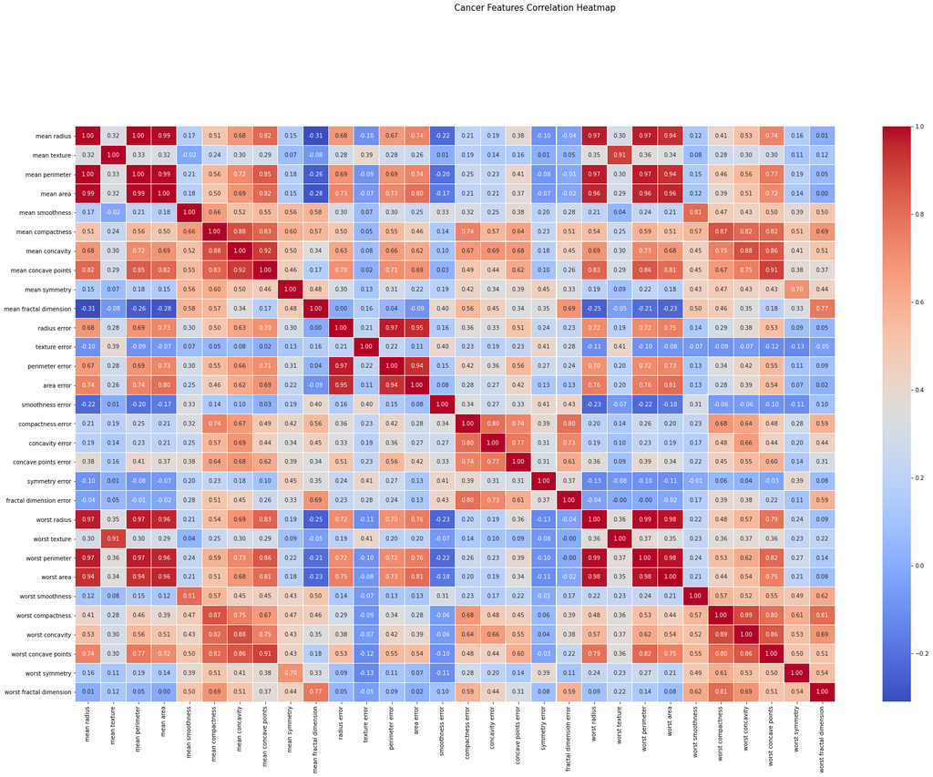

```python
# Create a correlation heatmap
f, ax = plt.subplots(figsize=(30, 20))
hm = sns.heatmap(round(corr,2), annot=True, ax=ax, cmap="coolwarm",fmt='.2f', linewidths=.05)
f.subplots_adjust(top=0.83)
t= f.suptitle('Cancer Features Correlation Heatmap', fontsize=15)
```

#### Answer

- From the heatmap, the mean-radius is highly and positively correlated with the mean-perimeter, the mean-area, the worst-radius, the worst-perimeter, the worst-area variables with the correlation values ranges 0.94 to 1, indicated with the red color in heatmap.
- The perimeter error and the area error are also highly correlated with the radius error.
- The mean-radius is moderately and positively correleated with the mean-compactness, the mean concavity, the radius error, the perimeter error, and the area error, indicated by the orange color in heatmap.
- There are low and positive correlatation in the mean-radius with mean-smoothness, compactness error, mean symmetry,worst-smoothness, worst-symmetry, worst fractal dimension which the correlation values are less than 0.2 and indicated by the blue color in heatmap.
- There are a low but negative correlation in the mean-radius with the mean fractal dimesion , the testure error, the smoothness error, the symmetry errors. etc with the negative correlation value and indicated by the darker blue color in heatmap.

### Question 5 [5 points]

**Train - Test split**

- Use sklearn's `tran_test_split()` function to create the split.
- Use `random_state = 40` to create consistent and repeatable train-test splits.
- What is the proportion of cancer classes in train and test sets after splitting? Are they equal or very close to each other?
- What is the importance of stratified sampling?

```python
# split the datasets into training and test data
X_train, X_test, y_train, y_test = train_test_split(X, y, stratify=y, random_state = 40, test_size= 0.25)
```

```python
# Code here
cnt_train = y_train.value_counts()
per_train = y_train.value_counts(normalize=True)
cnt_test = y_test.value_counts()
per_test = y_test.value_counts(normalize=True)

pd.DataFrame({'Train_Count': cnt_train,'Test_Count': cnt_test, 'Train_Percent': per_train, 'Test_Percent': per_test})
```

|  | Train_Count | Test_Count | Train_Percent | Test_Percent |
| --- | --- | --- | --- | --- |
| 0 | 267 | 90 | 0.626761 | 0.629371 |
| 1 | 159 | 53 | 0.373239 | 0.370629 |

#### Answer

- The proportion of the cancer class "1" is 37.32% in train set and 37.06% in test set.
- The proportions of the cancer class in train and test sets are very close to each other.
- The stratified sampling is important to ensure that each class within our samples (both in train and test sets) has a proper representation of the entire population.

### Question 6 [10 points]

- Initiate the logistic regression classifier from the sklearn library as shown below.
- Fit the model
- Make predictions
- Calculate accuracy score. What are the **training** and **testing** accuracies of the model?
- Create confusion matrix
- Either calculate using the confusion matrix, or use the methods in `metrics` to get the following metrics on the testing set:
  - Recall (Sensitivity)
  - Specificity
  - Precision
  - False Positive Rate
  - F1 Score

```python
from sklearn.linear_model import LogisticRegression
```

```python
clf = LogisticRegression(max_iter = 10000, solver='lbfgs', penalty='l2', C=0.1)
```

#### Fit the model

```python
clf.fit(X_train, y_train)
```

```
LogisticRegression(C=0.1, max_iter=10000)
```

#### Accuracy Score (Train)

```python
pred = clf.predict(X_train)
metrics.accuracy_score(y_true = y_train, y_pred = pred)
```

```
0.9577464788732394
```

#### Accuracy Score (Test)

```python
pred = clf.predict(X_test)
metrics.accuracy_score(y_true = y_test, y_pred = pred)
```

```
0.916083916083916
```

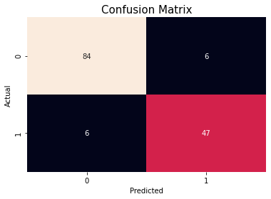

```python
# Code here
# Create confusion metrics
confusion_matrix =  pd.crosstab(index=np.ravel(y_test), columns=pred.ravel(), rownames=['Actual'], colnames=['Predicted'])
sns.heatmap(confusion_matrix, annot=True, square=False, fmt='', cbar=False)
plt.title("Confusion Matrix", fontsize = 15)
plt.show()
```

```python
# We can get metrics from the report which shows 2 classes
# Look at class1 for sensitivity, precision, f1-score
# Look at class 0 for specificity and FPR = 1-specificity
dc= metrics.classification_report(y_true = y_test, y_pred = pred, output_dict=True)
print("Sensitivity %.4f"%(dc['1']['recall']))
print("Specificity %.4f"%(dc['0']['recall']))
print("Precision %.4f"%(dc['1']['precision']))
print("False Positive Rate %.4f"%(1-dc['0']['recall']))
print("F1-score %.4f"%(dc['1']['f1-score']))
```

```
Sensitivity 0.8868
Specificity 0.9333
Precision 0.8868
False Positive Rate 0.0667
F1-score 0.8868
```

```python
#Calculate the metric scores
print(metrics.classification_report(y_true = y_test, y_pred = pred))
```

```
              precision    recall  f1-score   support

           0       0.93      0.93      0.93        90
           1       0.89      0.89      0.89        53

    accuracy                           0.92       143
   macro avg       0.91      0.91      0.91       143
weighted avg       0.92      0.92      0.92       143
```

### Answer:

- The accuracy of train set is 95.77% and The accuracy of test set is 91.60%
- The classification report shows the recall metrics: specificity is 93%, sensitivity is 89%.
- The accuracy from the train set is higher than that of test set. but both rates are still high which implies a good performance. We will further examine other metrics such as F1 score of test set for more details.
- From the metrics above, the model has a slightly better performance in predicting class 0 than class 1 with the higher specificity of 0.93 than sensitivity of 0.89.

### Question 7 [10 points]

- Initiate the k-nearest neighbours classifier from the sklearn library with n_neighbors=1. Keep the remaining parameters with their default values. (No need to specify anything)
- Fit the model
- Make predictions
- Calculate accuracy score. What are the **training** and **testing** accuracies of the model?
- Create confusion matrix
- Either calculate using the confusion matrix, or using the methods in `metrics` to get the following metrics on the testing set:
  - Recall (Sensitivity)
  - Specificity
  - Precision
  - F1 Score

```python
# Code here
from sklearn.neighbors import KNeighborsClassifier
```

```python
clf = KNeighborsClassifier(n_neighbors=1)
```

#### Fit model

```python
clf.fit(X_train, y_train)
```

```
KNeighborsClassifier(n_neighbors=1)
```

#### Accuracy score (Train)

```python
pred = clf.predict(X_train)
metrics.accuracy_score(y_true = y_train, y_pred = pred)
```

```
1.0
```

#### Accuracy score (Test)

```python
pred = clf.predict(X_test)
metrics.accuracy_score(y_true = y_test, y_pred = pred)
```

```
0.9020979020979021
```

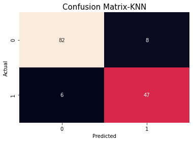

```python
# Create confusion metrics
confusion_matrix =  pd.crosstab(index=np.ravel(y_test), columns=pred.ravel(), rownames=['Actual'], colnames=['Predicted'])
sns.heatmap(confusion_matrix, annot=True, square=False, fmt='', cbar=False)
plt.title("Confusion Matrix-KNN", fontsize = 15)
plt.show()
```

```python
# We can get metrics from the report which shows 2 classes
# Look at class1 for sensitivity, precision, f1-score
# Look at class 0 for specificity and FPR = 1-specificity
dc= metrics.classification_report(y_true = y_test, y_pred = pred, output_dict=True)
print("Sensitivity %.4f"%(dc['1']['recall']))
print("Specificity %.4f"%(dc['0']['recall']))
print("Precision %.4f"%(dc['1']['precision']))
print("False Positive Rate %.4f"%(1-dc['0']['recall']))
print("F1-score %.4f"%(dc['1']['f1-score']))
```

```
Sensitivity 0.8868
Specificity 0.9111
Precision 0.8545
False Positive Rate 0.0889
F1-score 0.8704
```

```python
#Calculate the metric scores
print(metrics.classification_report(y_true = y_test, y_pred = pred))
```

```
              precision    recall  f1-score   support

           0       0.93      0.91      0.92        90
           1       0.85      0.89      0.87        53

    accuracy                           0.90       143
   macro avg       0.89      0.90      0.90       143
weighted avg       0.90      0.90      0.90       143
```

### Answer:

- The accuracy of train set is 100%
- The accuracy of test set is 90.20%
- The accuracy from the train set is higher than that of test set. but both rates are still high which implies a good performance. We will further examine other metrics such as F1 score of test set for more details.
- From the metrics above, the model has a slightly better performance in predicting class 0 than class 1 with the higher Specificity of 0.91 than Sensitivity 0.89.

### Question 8 [10 points]

- Initiate the Gaussian Naive Bayes classifier from the sklearn library. Keep all parameters with their default values. (No need to specify anything)
- Fit the model
- Make predictions
- Calculate accuracy score. What are the **training** and **testing** accuracies of the model?
- Create confusion matrix
- Either calculate using the confusion matrix, or using the methods in `metrics` to get the following metrics on the testing set:
  - Recall (Sensitivity)
  - Specificity
  - Precision
  - F1 Score

```python
# Code here
from sklearn.naive_bayes import GaussianNB
```

```python
clf_NB = GaussianNB()
```

#### Fit model

```python
clf_NB.fit(X_train, y_train)
```

```
GaussianNB()
```

#### Accuracy score (Train)

```python
pred = clf_NB.predict(X_train)
metrics.accuracy_score(y_true = y_train, y_pred = pred)
```

```
0.9483568075117371
```

#### Accuracy score (Test)

```python
pred = clf_NB.predict(X_test)
metrics.accuracy_score(y_true = y_test, y_pred = pred)
```

```
0.9300699300699301
```

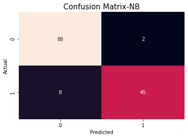

```python
# Create confusion metrics
# metrics.confusion_matrix(y_true = y_test, y_pred = pred)
confusion_matrix =  pd.crosstab(index=np.ravel(y_test), columns=pred.ravel(), rownames=['Actual'], colnames=['Predicted'])
sns.heatmap(confusion_matrix, annot=True, square=False, fmt='', cbar=False)
plt.title("Confusion Matrix-NB", fontsize = 15)
plt.show()
```

```python
# We can get metrics from the report which shows 2 classes
# Look at class1 for sensitivity, precision, f1-score
# Look at class 0 for specificity and FPR = 1-specificity
dc= metrics.classification_report(y_true = y_test, y_pred = pred, output_dict=True)
print("Sensitivity %.4f"%(dc['1']['recall']))
print("Specificity %.4f"%(dc['0']['recall']))
print("Precision %.4f"%(dc['1']['precision']))
print("False Positive Rate %.4f"%(1-dc['0']['recall']))
print("F1-score %.4f"%(dc['1']['f1-score']))
```

```
Sensitivity 0.8491
Specificity 0.9778
Precision 0.9574
False Positive Rate 0.0222
F1-score 0.9000
```

```python
#Calculate the metric scores
print(metrics.classification_report(y_true = y_test, y_pred = pred))
```

```
              precision    recall  f1-score   support

           0       0.92      0.98      0.95        90
           1       0.96      0.85      0.90        53

    accuracy                           0.93       143
   macro avg       0.94      0.91      0.92       143
weighted avg       0.93      0.93      0.93       143
```

### Answer:

- The accuracy of train set is 94.83%
- The accuracy of test set is 93.00%
- The accuracy from the train set is higher than that of test set. but both rates are still high which implies a good performance. We will further examine other metrics of test set for more details.
- From the metrics above, the model has a slightly better performance in predicting class 0 than class 1 with the higher Specificity of 0.98 than Sensitivity 0.85.

### Question 9 [10 points]

In logistic regression keeping the other parameters constant try these values for C: `C_list = [0.0001, 0.0005, 0.001, 0.005, 0.01, 0.05, 0.1, 0.5, 1, 2, 10, 50, 100, 200, 500, 1000, 2000, 5000, 10000]`.  
C is the inverse of the regularization parameter $\lambda$. As C increases, the penalty decreases.

- Create a loop and fit the models using each C value.
- Make predictions
- Calculate accuracy scores for **training** and **testing** datasets. Create a list of accuracy results for train and test accuracies. Show these lists.
- Plot the validation curve based on each C value and the corresponding the train and test accuracies.

  > Create this curve yourself. Do not use sklearn built-in function.

```python
C_list = [0.0001, 0.0005, 0.001, 0.005, 0.01, 0.05, 0.1, 0.5, 1, 2, 10, 50, 100, 200, 500, 1000, 2000, 5000, 10000]
accuracy_train = []
accuracy_test = []
for C in C_list:
    clf = LogisticRegression(max_iter = 10000, solver='lbfgs', penalty='l2', C=C)
    # Code here
    clf.fit(X_train, y_train)
    pred_train = clf.predict(X_train)
    accuracy_train.append(metrics.accuracy_score(y_true = y_train, y_pred = pred_train))
    pred_test = clf.predict(X_test)
    accuracy_test.append(metrics.accuracy_score(y_true = y_test, y_pred = pred_test))
```

#### Accuracy Score (Train)

```python
accuracy_train
```

```
[0.9366197183098591,
 0.9413145539906104,
 0.9507042253521126,
 0.9553990610328639,
 0.9530516431924883,
 0.9577464788732394,
 0.9577464788732394,
 0.9647887323943662,
 0.9671361502347418,
 0.9694835680751174,
 0.9694835680751174,
 0.9765258215962441,
 0.9859154929577465,
 0.9859154929577465,
 0.9882629107981221,
 0.9882629107981221,
 0.9906103286384976,
 0.9906103286384976,
 0.9882629107981221]
```

#### Accuracy Score (Test)

```python
accuracy_test
```

```
[0.8881118881118881,
 0.9020979020979021,
 0.9090909090909091,
 0.916083916083916,
 0.916083916083916,
 0.916083916083916,
 0.916083916083916,
 0.916083916083916,
 0.916083916083916,
 0.9230769230769231,
 0.9230769230769231,
 0.9300699300699301,
 0.9300699300699301,
 0.9300699300699301,
 0.9230769230769231,
 0.9300699300699301,
 0.9370629370629371,
 0.9230769230769231,
 0.9370629370629371]
```

The best C value is 2000, 10000 with the highest accuracy of test set of 93.7%.

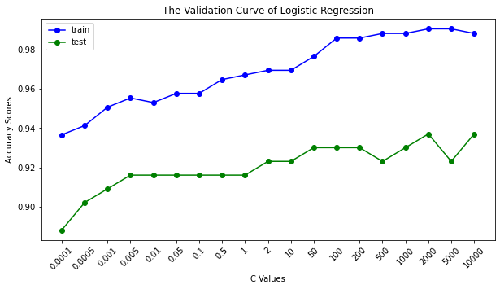

```python
# Code here
plt.figure(figsize=(10,5))
plt.title("The Validation Curve of Logistic Regression")
plt.plot(accuracy_train, 'bo-', label = 'train')
plt.plot(accuracy_test,'go-', label = 'test')
plt.xticks(np.arange(len(C_list)), C_list, rotation =45)
plt.xlabel('C Values')
plt.ylabel('Accuracy Scores')
plt.legend()
plt.show()
```

### Question 10 [10 points]

In K Nearest Neighbors keeping the other parameters constant try these values for K (n_neighbors): `K_list = [1,3,5,7,9,15,19,25,29,35,39,45,49,99]`.

- Create a loop and fit the models using each K value.
- Make predictions
- Calculate accuracy scores for **training** and **testing** datasets. Create a list of accuracy results for train and test accuracies. Show these lists.
- Create the validation curve based on each K value and the corresponding the train and test accuracies.

  > Create this curve yourself. Do not use sklearn built-in function.

```python
K_list = [1,3,5,7,9,15,19,25,29,35,39,45,49,99]
accuracy_train = []
accuracy_test = []
for K in K_list:
    clf = KNeighborsClassifier(n_neighbors=K)
    # Code here
    clf.fit(X_train, y_train)
    pred_train = clf.predict(X_train)
    accuracy_train.append(metrics.accuracy_score(y_true = y_train, y_pred = pred_train))
    pred_test = clf.predict(X_test)
    accuracy_test.append(metrics.accuracy_score(y_true = y_test, y_pred = pred_test))
```

#### Accuracy score (Train)

```python
# accuracy_train
accuracy_train
```

```
[1.0,
 0.960093896713615,
 0.9530516431924883,
 0.9507042253521126,
 0.9436619718309859,
 0.9413145539906104,
 0.9389671361502347,
 0.9389671361502347,
 0.9342723004694836,
 0.9342723004694836,
 0.9295774647887324,
 0.9295774647887324,
 0.9225352112676056,
 0.9178403755868545]
```

#### Accuracy Score (test)

```python
# accuracy_test
accuracy_test
```

```
[0.9020979020979021,
 0.9090909090909091,
 0.9090909090909091,
 0.9020979020979021,
 0.8951048951048951,
 0.9020979020979021,
 0.9020979020979021,
 0.8951048951048951,
 0.8881118881118881,
 0.8881118881118881,
 0.8951048951048951,
 0.8951048951048951,
 0.8881118881118881,
 0.8671328671328671]
```

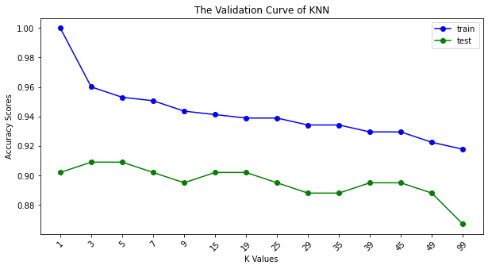

```python
# Code here
plt.figure(figsize=(10,5))
plt.title("The Validation Curve of KNN")
plt.plot(accuracy_train, 'bo-', label = 'train')
plt.plot(accuracy_test,'go-', label = 'test')
plt.xticks(np.arange(len(K_list)), K_list, rotation = 45)
plt.xlabel('K Values')
plt.ylabel('Accuracy Scores')
plt.legend()
plt.show()
```

The best K value is 3,5 with the highest accuracy of test set of 90.9%.

### Question 11 [10 points]

- The validation curve for logistic regression seems a bit weird. That might have to do with the fact that the data is not normalized.
- Apply standardization to the data and re-do Quesion 9 and plot the validation curve for logistic regression models with same parameter range for C.
- Plot the validation curve. What do you see?
- Which value would you choose for C in logistic regression? Why?

```python
from sklearn import preprocessing
```

```python
ss = preprocessing.StandardScaler()
X_train_ss = ss.fit_transform(X_train)
X_test_ss = ss.transform(X_test)
```

```python
# Code here
C_list = [0.0001, 0.0005, 0.001, 0.005, 0.01, 0.05, 0.1, 0.5, 1, 2, 10, 50, 100, 200, 500, 1000, 2000, 5000, 10000]
accuracy_train_ss = []
accuracy_test_ss = []
for C in C_list:
    clf = LogisticRegression(max_iter = 10000, solver='lbfgs', penalty='l2', C=C)
    clf.fit(X_train_ss, y_train)
    pred_train_ss = clf.predict(X_train_ss)
    accuracy_train_ss.append(metrics.accuracy_score(y_true = y_train, y_pred = pred_train_ss))
    pred_test_ss = clf.predict(X_test_ss)
    accuracy_test_ss.append(metrics.accuracy_score(y_true = y_test, y_pred = pred_test_ss))
```

```python
accuracy_train_ss
```

```
[0.6455399061032864,
 0.8450704225352113,
 0.892018779342723,
 0.9483568075117371,
 0.9553990610328639,
 0.9788732394366197,
 0.9859154929577465,
 0.9953051643192489,
 0.9929577464788732,
 0.9929577464788732,
 0.9929577464788732,
 0.9976525821596244,
 1.0,
 1.0,
 1.0,
 1.0,
 1.0,
 1.0,
 1.0]
```

```python
accuracy_test_ss
```

```
[0.6293706293706294,
 0.7832167832167832,
 0.8811188811188811,
 0.9370629370629371,
 0.9440559440559441,
 0.9440559440559441,
 0.951048951048951,
 0.958041958041958,
 0.965034965034965,
 0.951048951048951,
 0.9370629370629371,
 0.9440559440559441,
 0.9440559440559441,
 0.9370629370629371,
 0.9370629370629371,
 0.9370629370629371,
 0.9370629370629371,
 0.9370629370629371,
 0.9370629370629371]
```

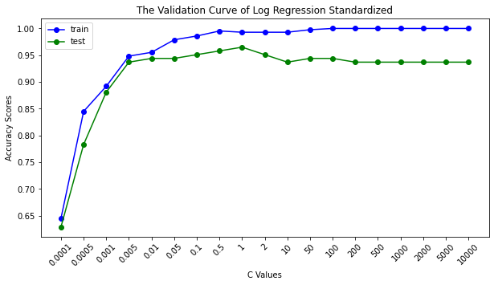

```python
# Code here
plt.figure(figsize=(10,5))
plt.title("The Validation Curve of Log Regression Standardized")
plt.plot(accuracy_train_ss, 'bo-', label = 'train')
plt.plot(accuracy_test_ss,'go-', label = 'test')
plt.xticks(np.arange(len(C_list)), C_list, rotation = 45)
plt.xlabel('C Values')
plt.ylabel('Accuracy Scores')
plt.legend()
plt.show()
```

### Answer

- The validation curve shows that when C < 1, the model is underfitting.
- The C = 1 is an optimal point, and when the C > 1, the model is overfitting.
- I choose C value = 1 as an optimal point, which the accuracy score of test set is highest (96.5%).
- Beyond this point, the model starts overfitting as the accuracy score of test set is decreasing.

### Question 12 [5 points]

```python
X_train_ss.shape
```

```
(426, 30)
```

```python
X_train_ss[0:426,:].shape
```

```
(426, 30)
```

- After choosing your best C value, let's check the learning curve.
- Create a logistic regression model of your chosen C value, and the other parameters the same as before.
- Starting from 1 data point in the training set, increase your training set size by 1 point in each iteration, fit the model, get the accuracy scores for both the current training and test sets.
- Increase the training set size consecutively. Do not randomly select data points. (`X_train_ss[0:N,:] where N = {1,2,3,...,len(X_train_ss)}`)
- Plot the learning curve. What do you see? Comment on your finding.

```python
X_train_ss.shape
```

```
(426, 30)
```

```python
# Code here
# Incremented the train set size by 1
# Fit the model with C value = 1
N_list = np.arange(2,len(X_train_ss)+1,1).tolist()
accuracy_train_ss = []
accuracy_test_ss = []
for N in N_list:
    clf = LogisticRegression(max_iter = 10000, solver='lbfgs', penalty='l2', C=1)
    clf.fit(X_train_ss[0:N,:], y_train[0:N])
    pred_train_ss = clf.predict(X_train_ss[0:N,:])
    accuracy_train_ss.append(metrics.accuracy_score(y_true = y_train[0:N], y_pred = pred_train_ss))
    pred_test_ss = clf.predict(X_test_ss)
    accuracy_test_ss.append(metrics.accuracy_score(y_true = y_test, y_pred = pred_test_ss))
```

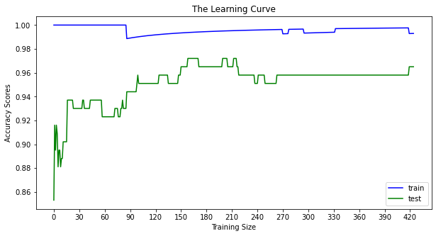

```python
# Code here
plt.figure(figsize=(10,5))
plt.title("The Learning Curve")
plt.plot(accuracy_train_ss, 'b-', label = 'train')
plt.plot(accuracy_test_ss,'g-', label = 'test')
plt.xticks(np.arange(0, len(N_list), step=30))
plt.xlabel('Training Size')
plt.ylabel('Accuracy Scores')
plt.legend()
plt.show()
```

### Question 13 [5 points]

- Before applying KNN, it is important to scale the features.
- Use the standardized train and test sets re-do Quesion 10 and plot the validation curve for KNN models with same parameter range for K.
- Plot the validation curve. What do you see?
- Which value would you choose for K in nearest neighbor model?

```python
# Code here
ss = preprocessing.StandardScaler()
X_train_ss = ss.fit_transform(X_train)
X_test_ss = ss.transform(X_test)
K_list = [1,3,5,7,9,15,19,25,29,35,39,45,49,99]
accuracy_train_ss = []
accuracy_test_ss = []
for K in K_list:
    clf = KNeighborsClassifier(n_neighbors=K)
    # Code here
    clf.fit(X_train_ss, y_train)
    pred_train_ss = clf.predict(X_train_ss)
    accuracy_train_ss.append(metrics.accuracy_score(y_true = y_train, y_pred = pred_train_ss))
    pred_test_ss = clf.predict(X_test_ss)
    accuracy_test_ss.append(metrics.accuracy_score(y_true = y_test, y_pred = pred_test_ss))
```

```python
# accuracy_train
accuracy_train_ss
```

```
[1.0,
 0.9882629107981221,
 0.9788732394366197,
 0.9765258215962441,
 0.9765258215962441,
 0.9647887323943662,
 0.9577464788732394,
 0.9507042253521126,
 0.9553990610328639,
 0.9577464788732394,
 0.9577464788732394,
 0.9507042253521126,
 0.9507042253521126,
 0.9272300469483568]
```

```python
# accuracy_test
accuracy_test_ss
```

```
[0.9370629370629371,
 0.951048951048951,
 0.951048951048951,
 0.951048951048951,
 0.958041958041958,
 0.9440559440559441,
 0.9440559440559441,
 0.9440559440559441,
 0.9440559440559441,
 0.9440559440559441,
 0.9440559440559441,
 0.9440559440559441,
 0.9440559440559441,
 0.9230769230769231]
```

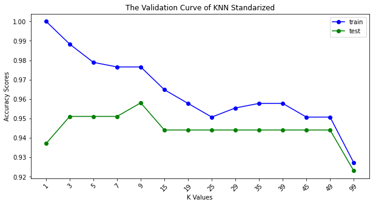

```python
# Code here
plt.figure(figsize=(10,5))
plt.title("The Validation Curve of KNN Standarized")
plt.plot(accuracy_train_ss, 'bo-', label = 'train')
plt.plot(accuracy_test_ss,'go-', label = 'test')
plt.xticks(np.arange(len(K_list)), K_list, rotation = 45)
plt.xlabel('K Values')
plt.ylabel('Accuracy Scores')
plt.legend()
plt.show()
```

### Question 14 [10 points]

- Using only the classifier models of logistic regression, Gaussian Naive Bayes, or KNN models:
  - Think of other ways of improving the accuracy and list at least two possibilities.
  - Implement one of the methods you proposed.
  - Is the model accuracy increasing? Why do you think this might have helped?
  - If it not increasing, try the other method you proposed. Why do you think this might have helped?
  - If none of them did not improve, comment on why this might have been the case.
  - If you have time try a few more solutions and see which one works.

### Method 1: Stratified Cross-Validation

- To split the original train set to avoid overfitting and information leakage, so the model will accurately evaluated in each training
- We should do Stratified Cross-Validation on the train set to ensure all the labels are equally represented.
- Stratified Cross-Validation provides better accuracy which the variance is lower, so it is better than a single train test split and ensure the proper representation of each class
- To find the best hyper-parameter for log-regression, the model will fit with Stratified 5-folds Cross-validation with the logistic regression using the same parameters and the same standardized X value like Question 11.
- The comparision on both models are shown below.

```python
# Standarized the X first, then initialized 5-fold Stratified Cross-Validation
ss = preprocessing.StandardScaler()
X_ss = ss.fit_transform(X_train).tolist()
skf = StratifiedKFold(n_splits=5, random_state=40)
skf.get_n_splits(X_ss, y_train)
```

```
5
```

```python
# Hyper-parameter tuning with 5-fold Stratified Cross-Validation
# The accuracy scores are the mean accuracy from each fold
C_list = [0.0001, 0.0005, 0.001, 0.005, 0.01, 0.05, 0.1, 0.5, 1, 2, 10, 50, 100, 200, 500, 1000, 2000, 5000, 10000]
accuracy_valid = []
for C in C_list:
    clf = LogisticRegression(max_iter = 10000, solver='lbfgs', penalty='l2', C=C)
    score_valid= cross_val_score(clf,X_ss, y_train, scoring = "accuracy", cv =skf )
    accuracy_valid.append(score_valid.mean())
```

```python
accuracy_valid
```

```
[0.6291108071135431,
 0.8169357045143639,
 0.8779480164158688,
 0.9436935704514365,
 0.9530506155950753,
 0.9671682626538989,
 0.9765526675786594,
 0.9765526675786594,
 0.9812311901504789,
 0.9765253077975377,
 0.962407660738714,
 0.9600547195622434,
 0.9553488372093023,
 0.9529958960328317,
 0.9529958960328317,
 0.9506429548563611,
 0.9506429548563611,
 0.9529958960328317,
 0.9529958960328317]
```

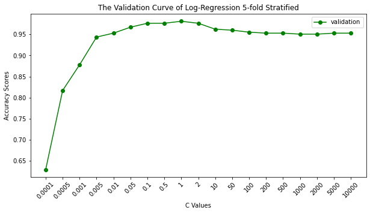

```python
# Code here
plt.figure(figsize=(10,5))
plt.title("The Validation Curve of Log-Regression 5-fold Stratified")
plt.plot(accuracy_valid, 'go-',label = 'validation')
plt.xticks(np.arange(len(C_list)), C_list, rotation = 45)
plt.xlabel('C Values')
plt.ylabel('Accuracy Scores')
plt.legend()
plt.show()
```

```python
# Refit the data with C=1
ss = preprocessing.StandardScaler()
X_train_ss = ss.fit_transform(X_train)
X_test_ss = ss.transform(X_test)
clf = LogisticRegression(max_iter = 10000, solver='lbfgs', penalty='l2', C=1)
clf.fit(X_train_ss, y_train)
pred = clf.predict(X_train_ss)
print("Accuracy of Train set: " ,metrics.accuracy_score(y_true = y_train, y_pred = pred))
pred = clf.predict(X_test_ss)
print("Accuracy of Test set: " , metrics.accuracy_score(y_true = y_test, y_pred = pred))
```

```
Accuracy of Train set:  0.9929577464788732
Accuracy of Test set:  0.965034965034965
```

### Method 2: Select the best features to fit model

```python
model = ExtraTreesClassifier(n_estimators=100)
model.fit(X, y)
print(model.feature_importances_)
```

```
[0.05521225 0.02272013 0.04423623 0.04055699 0.01100921 0.01855267
 0.04942491 0.07762279 0.00895946 0.00636686 0.02022928 0.00550365
 0.02308076 0.04959303 0.00573297 0.01061489 0.01216582 0.00638408
 0.00566709 0.00530036 0.12543657 0.02134309 0.10259104 0.06741675
 0.02103861 0.01654569 0.04896734 0.09206649 0.01548297 0.01017801]
```

```python
cols = [8,9,11,14,15,16,19]
new_X = X_train.drop(columns=X_train.columns[cols])
```

```python
# Standarized data and initialized Stratified 5 folds
ss = preprocessing.StandardScaler()
X_ss = ss.fit_transform(new_X).tolist()

skf = StratifiedKFold(n_splits=5, random_state=40)
skf.get_n_splits(X_ss, y_train)
```

```
5
```

```python
# Refit the data with a few features of Xs and with Stratified 5 folds to find the best C value
C_list = [0.0001, 0.0005, 0.001, 0.005, 0.01, 0.05, 0.1, 0.5, 1, 2, 10, 50, 100, 200, 500, 1000, 2000, 5000, 10000]
accuracy_ss = []
for C in C_list:
    clf = LogisticRegression(max_iter = 10000, solver='lbfgs', penalty='l2', C=C)
    score_train= cross_val_score(clf,X_ss, y_train, scoring = "accuracy", cv =skf )
    accuracy_ss.append(score_train.mean())
```

```python
accuracy_ss
```

```
[0.6291108071135431,
 0.8122571819425446,
 0.880328317373461,
 0.9436662106703148,
 0.9506976744186048,
 0.9718194254445965,
 0.9765253077975377,
 0.9835841313269494,
 0.9788508891928865,
 0.9764979480164158,
 0.9717920656634746,
 0.9600547195622434,
 0.9529958960328317,
 0.9459370725034197,
 0.9482900136798904,
 0.9459370725034197,
 0.94593707250342,
 0.9435841313269494,
 0.9435841313269494]
```

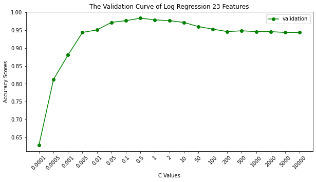

```python
# Code here
plt.figure(figsize=(10,5))
plt.title("The Validation Curve of Log Regression 23 Features")
plt.plot(accuracy_ss, 'go-' ,label = 'validation')
plt.xticks(np.arange(len(C_list)), C_list, rotation = 45)
plt.xlabel('C Values')
plt.ylabel('Accuracy Scores')
plt.legend()
plt.show()
```

```python
# Refit the data with C= 0.5 with 23 features
cols = [8,9,11,14,15,16,19]
new_X = X_train.drop(columns=X_train.columns[cols])
new_X_test = X_test.drop(columns=X_train.columns[cols])
ss = preprocessing.StandardScaler()
X_train_ss = ss.fit_transform(new_X)
X_test_ss = ss.transform(new_X_test)
clf = LogisticRegression(max_iter = 10000, solver='lbfgs', penalty='l2', C=0.5)
clf.fit(X_train_ss, y_train)
pred = clf.predict(X_train_ss)
print("Accuracy of Train set: " ,metrics.accuracy_score(y_true = y_train, y_pred = pred))
pred = clf.predict(X_test_ss)
print("Accuracy of Test set: " , metrics.accuracy_score(y_true = y_test, y_pred = pred))
```

```
Accuracy of Train set:  0.9882629107981221
Accuracy of Test set:  0.951048951048951
```